# Data 624 - Assignment 5

John Kellogg

3/12/2021

## Assignment

Complete these questions from the Hyndman Text book: 7.1, 7.5,7.6, 7.7, 7.8 and 7.9

## 7.1

Consider the pigs series — the number of pigs slaughtered in Victoria each month.

### a.

Use the ses() function in R to find the optimal values of $\alpha$ and $l _{0}$, and generate forecasts for the next four months.

```r
sub_pigs <- ses(pigs, h=4)
summary(sub_pigs)
```

```
##
## Forecast method: Simple exponential smoothing
##
## Model Information:
## Simple exponential smoothing
##
## Call:
##  ses(y = pigs, h = 4)
##
##   Smoothing parameters:
##     alpha = 0.2971
##
##   Initial states:
##     l = 77260.0561
##
##   sigma:  10308.58
##
##      AIC     AICc      BIC
## 4462.955 4463.086 4472.665
##
## Error measures:
##                    ME    RMSE      MAE       MPE     MAPE      MASE
## Training set 385.8721 10253.6 7961.383 -0.922652 9.274016 0.7966249
##                    ACF1
## Training set 0.01282239
##
## Forecasts:
##          Point Forecast    Lo 80    Hi 80    Lo 95    Hi 95
## Sep 1995       98816.41 85605.43 112027.4 78611.97 119020.8
## Oct 1995       98816.41 85034.52 112598.3 77738.83 119894.0
## Nov 1995       98816.41 84486.34 113146.5 76900.46 120732.4
## Dec 1995       98816.41 83958.37 113674.4 76092.99 121539.8
```

- The optimal $\alpha$ is 0.2971
- The optimal $l _{0}$ is 77260.0561

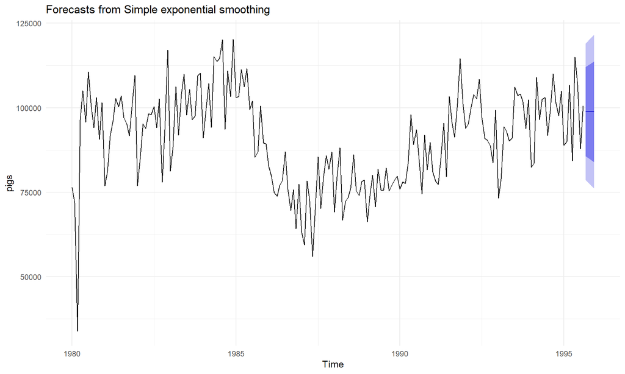

```r
autoplot(sub_pigs) + theme_minimal()
```

### b.

Compute a 95% prediction interval for the first forecast using $\hat{y}\pm 1.96s$ where s is the standard deviation of the residuals. Compare your interval with the interval produced by R.

```r
sd <- sd(residuals(sub_pigs))
ci <- c(Lower = sub_pigs$mean[1] - 1.96*sd, Upper = sub_pigs$mean[1] + 1.96*sd)
ci_r <- c(sub_pigs$lower[1,2], sub_pigs$upper[1,2])
names(ci_r) <- c("Lower", "Upper")
q7.1 <- data.frame(ci_r, ci)
names(q7.1) <- c("Confidence R", "Confidence Manual")

kable(q7.1, caption = "95% Confidence check")
```

95% Confidence check

|  | Confidence R | Confidence Manual |
| --- | --- | --- |
| Lower | 78611.97 | 78679.97 |
| Upper | 119020.84 | 118952.84 |

- R factors degrees if freedom in calculating variance, thus the numbers are higher.

## 7.5

Data set `books` contains the daily sales of paperback and hardcover books at the same store. The task is to forecast the next four days’ sales for paperback and hardcover books.

### a.

Plot the series and discuss the main features of the data.

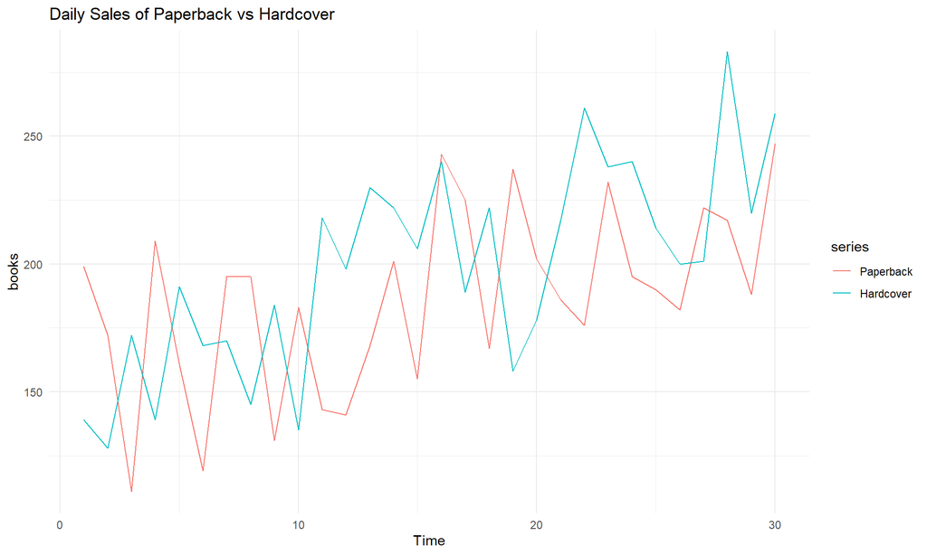

```r
autoplot(books) + theme_minimal()+
  labs(title = "Daily Sales of Paperback vs Hardcover")
```

- The data does show a upwards trend
- No Seasonality present
- Hardcover did start to out sale paperback toward the end of the month
- Values are very sporadic on both.

### b.

Use the ses() function to forecast each series, and plot the forecasts.

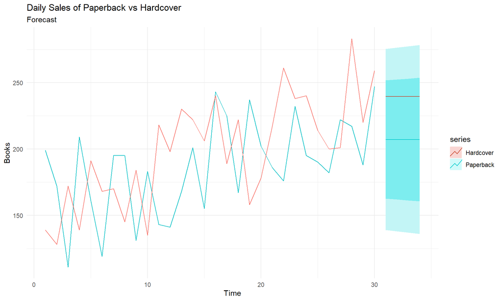

```r
paper_ses <- ses(books[,"Paperback"], h=4)
hard_ses <- ses(books[,"Hardcover"], h=4)

autoplot(books[,"Paperback"], series = "Paperback")+
  autolayer(paper_ses, series = "Paperback")+
  autolayer(books[,'Hardcover'], series = "Hardcover")+
  autolayer(hard_ses, series = "Hardcover", PI = FALSE)+
  theme_minimal()+
  labs(title = "Daily Sales of Paperback vs Hardcover", subtitle = "Forecast")+
  ylab("Books")
```

- With the sporadic nature of the data, no clear forecast can be achieved.

### c.

Compute the RMSE values for the training data in each case.

#### Paperback RMSE

```r
(paper_rmse <- sqrt(mean(residuals(paper_ses)^2)))
```

```
## [1] 33.63769
```

#### Hardcover RMSE

```r
(hard_rmse <- sqrt(mean(residuals(hard_ses)^2)))
```

```
## [1] 31.93101
```

- The RMSE value for Hardcover is lower and is the better number

## 7.6

### a.

Now apply Holt’s linear method to the paperback and hardback series and compute four-day forecasts in each case.

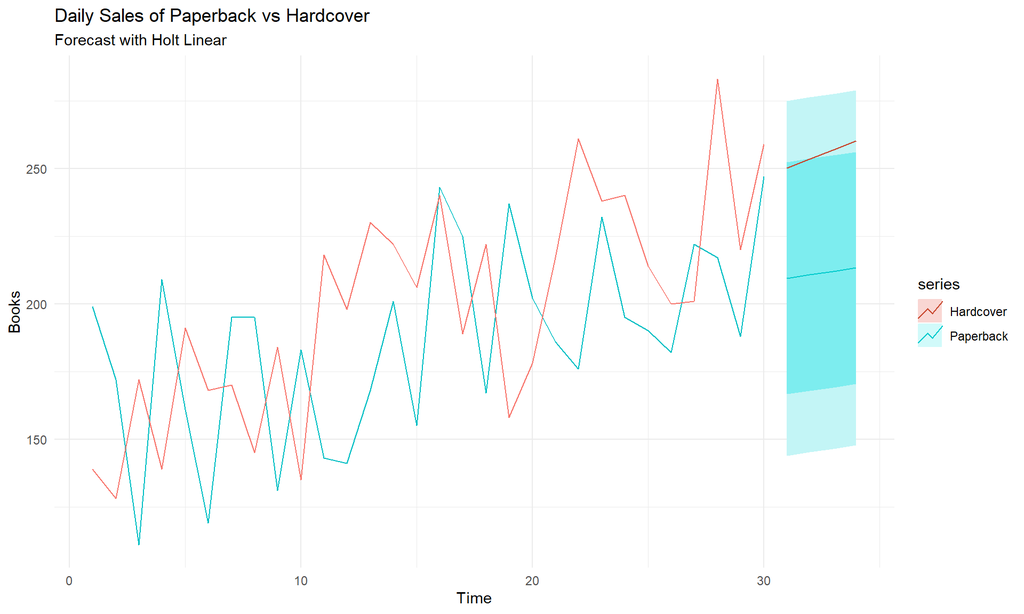

```r
paper_holt <- holt(books[,"Paperback"], h=4)
hard_holt <- holt(books[,"Hardcover"], h=4)

autoplot(books[,"Paperback"], series = "Paperback")+
  autolayer(paper_holt, series = "Paperback")+
  autolayer(books[,'Hardcover'], series = "Hardcover")+
  autolayer(hard_holt, series = "Hardcover", PI = FALSE)+
  theme_minimal()+
  labs(title = "Daily Sales of Paperback vs Hardcover", subtitle = "Forecast with Holt Linear")+
  ylab("Books")
```

- The Holt linear method now gives the forecast the same upwards trajectory we see in the data
- I would still not call the projection precise enough

### b.

Compare the RMSE measures of Holt’s method for the two series to those of simple exponential smoothing in the previous question.

(Remember that Holt’s method is using one more parameter than SES.) Discuss the merits of the two forecasting methods for these data sets.

```r
paper_rmse_holt <- sqrt(mean(residuals(paper_holt)^2))
hard_rmse_holt <- sqrt(mean(residuals(hard_holt)^2))

rmse_figures <- data.frame(Paperback = c(paper_rmse, paper_rmse_holt),
                             Hardcover = c(hard_rmse, hard_rmse_holt),
                             row.names = c("SES", "Holt"))

kable(rmse_figures, caption = "RMSE - SES vs Holt")
```

RMSE - SES vs Holt

|  | Paperback | Hardcover |
| --- | --- | --- |
| SES | 33.63769 | 31.93101 |
| Holt | 31.13692 | 27.19358 |

- The Holt method produces a lower RMSE
- Using this method, Holt method is the one of choice

### c.

Compare the forecasts for the two series using both methods. Which do you think is best?

```r
books_forecast <- data.frame(Paperback = c(paper_ses$mean[1], paper_holt$mean[1]),
                             Hardcover = c(hard_ses$mean[1], hard_holt$mean[1]),
                             row.names = c("SES", "Holt"))
kable(books_forecast, caption = "SES vs Holt")
```

SES vs Holt

|  | Paperback | Hardcover |
| --- | --- | --- |
| SES | 207.1097 | 239.5601 |
| Holt | 209.4668 | 250.1739 |

- The Forecasts for Holt Method is higher
- Choice would fall to Holt of the two

### d.

Calculate a 95% prediction interval for the first forecast for each series, using the RMSE values and assuming normal errors. Compare your intervals with those produced using ses and holt .

```r
s <- accuracy(paper_holt)[1,"RMSE"]
RMSE_paper <- c(Lower = paper_holt$mean[1] - 1.96*s, Upper = paper_holt$mean[1] + 1.96*s)
s <- accuracy(hard_holt)[1,"RMSE"]
RMSE_hard <- c(Lower = hard_holt$mean[1] - 1.96*s, Upper = hard_holt$mean[1] + 1.96*s)

ses_conf_paper <- round(c(paper_ses$lower[1,2], paper_ses$upper[1,2]),2)
names(ses_conf_paper) <- c("Lower", "Upper")
ses_conf_hard <- round(c(hard_ses$lower[1,2], hard_ses$upper[1,2]),2)
names(ses_conf_hard) <- c("Lower", "Upper")

holt_conf_paper <- round(c(paper_holt$lower[1,2], paper_holt$upper[1,2]),2)
names(holt_conf_paper) <- c("Lower", "Upper")
holt_conf_hard <- round(c(hard_holt$lower[1,2], hard_holt$upper[1,2]),2)
names(holt_conf_hard) <- c("Lower", "Upper")

conf95_figures <- data.frame('RMSE Paperback' = RMSE_paper,
                             'RMSE Hard Cover' = RMSE_hard,
                             'SES Paperback' = ses_conf_paper,
                             'SES Hard Cover' = ses_conf_hard,
                             'Holt Paperback' = holt_conf_paper,
                             'Holt Hard Cover' = holt_conf_hard,
                             row.names = c("Lower", "Upper"))
conf95_figures <- as.data.frame(t(conf95_figures))

kable(conf95_figures, caption = "95% Confidence comparison")
```

95% Confidence comparison

|  | Lower | Upper |
| --- | --- | --- |
| RMSE.Paperback | 148.4384 | 270.4951 |
| RMSE.Hard.Cover | 196.8745 | 303.4733 |
| SES.Paperback | 138.8700 | 275.3500 |
| SES.Hard.Cover | 174.7800 | 304.3400 |
| Holt.Paperback | 143.9100 | 275.0200 |
| Holt.Hard.Cover | 192.9200 | 307.4300 |

## 7.7

For this exercise use data set eggs , the price of a dozen eggs in the United States from 1900–1993. Experiment with the various options in the holt() function to see how much the forecasts change with damped trend, or with a Box-Cox transformation. Try to develop an intuition of what each argument is doing to the forecasts.

[Hint: use h=100 when calling holt() so you can clearly see the differences between the various options when plotting the forecasts.]

Which model gives the best RMSE?

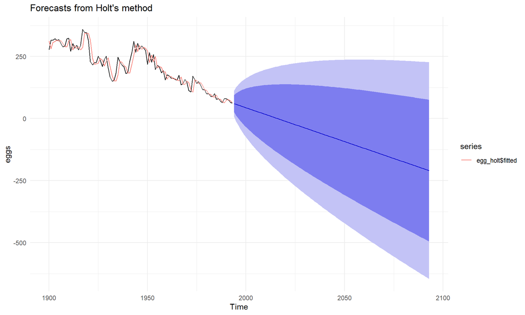

```r
egg_holt <- holt(eggs, h=100)
autoplot(egg_holt)+
  autolayer(egg_holt$fitted)+
  theme_minimal()
```

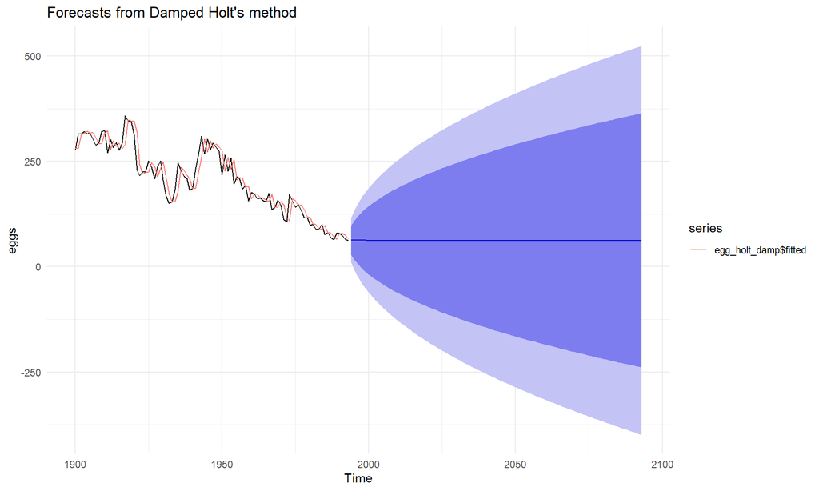

```r
egg_holt_damp <- holt(eggs, damped = TRUE, h=100)
autoplot(egg_holt_damp)+
  autolayer(egg_holt_damp$fitted)+
  theme_minimal()
```

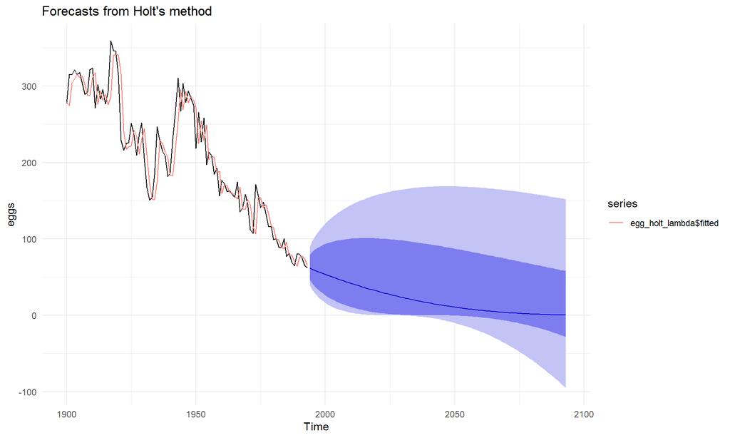

```r
egg_holt_lambda <- holt(eggs, lambda = BoxCox.lambda(eggs), h=100)
autoplot(egg_holt_lambda)+
  autolayer(egg_holt_lambda$fitted)+
  theme_minimal()
```

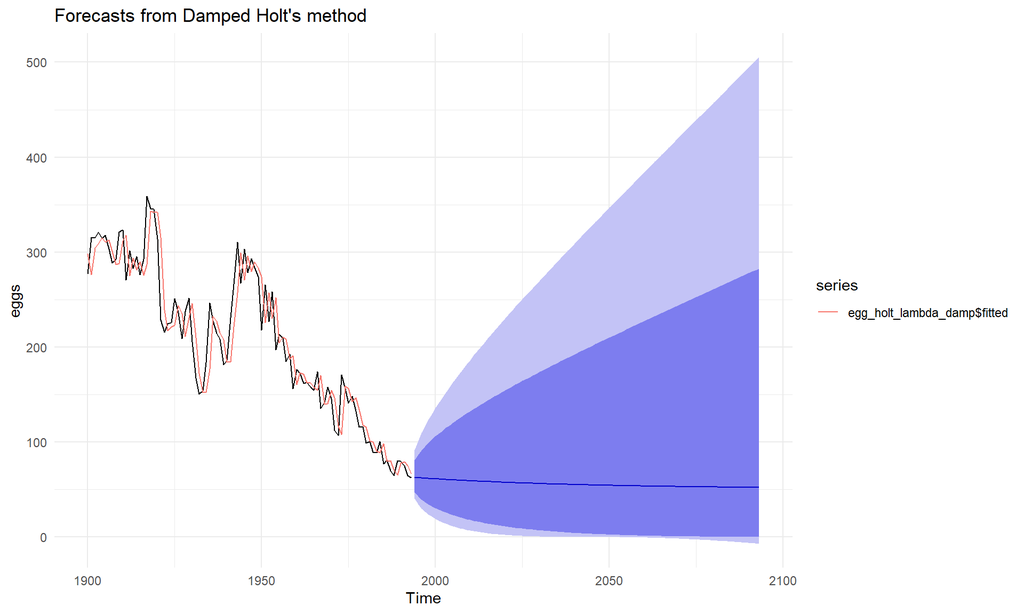

```r
egg_holt_lambda_damp <- holt(eggs, lambda = BoxCox.lambda(eggs), damped = TRUE, h=100)
autoplot(egg_holt_lambda_damp)+
  autolayer(egg_holt_lambda_damp$fitted)+
  theme_minimal()
```

```r
e_holt <- accuracy(egg_holt)[2]
e_damp <- accuracy(egg_holt_damp) [2]
e_lamb <- accuracy(egg_holt_lambda) [2]
e_lam_dam <- accuracy(egg_holt_lambda_damp)[2]

answer <- data.frame(Holt = e_holt,
                     'Holt Damped' = e_damp,
                     'Holt Lambda' = e_lamb,
                     'Holt Lambda Damped' = e_lam_dam)
answer <- as.data.frame(t(answer))

colnames(answer) <- c("Compare")

kable(answer, caption = "Comparison of Holt models")
```

Comparison of Holt models

|  | Compare |
| --- | --- |
| Holt | 26.58219 |
| Holt.Damped | 26.54019 |
| Holt.Lambda | 26.39376 |
| Holt.Lambda.Damped | 26.53321 |

- The Box Cox Lambda model produced the best RMSE
- In comparing the other models on graphs alone:
  - The Fitted model was moving in the direction of the trend, it was too straight to fit the data
  - The damped model did not move in the direction of the data but in a horizontal line from it
  - The Box Cox Lambda damped model had more of a curve to the prediction but still moved in a mostly horizontal line and not in the direction of the data
  - The Box Cox Lambda model moved in the direction of the data and had a slight curve as seen in the data

## 7.8

Recall your retail time series data (from Exercise 3 in Section 2.10).

```r
retaildata <- read_excel('retail.xlsx', skip=1)
myts <- ts(retaildata[,"A3349398A"],frequency=12, start=c(1982,4))
```

### a.

Why is multiplicative seasonality necessary for this series?

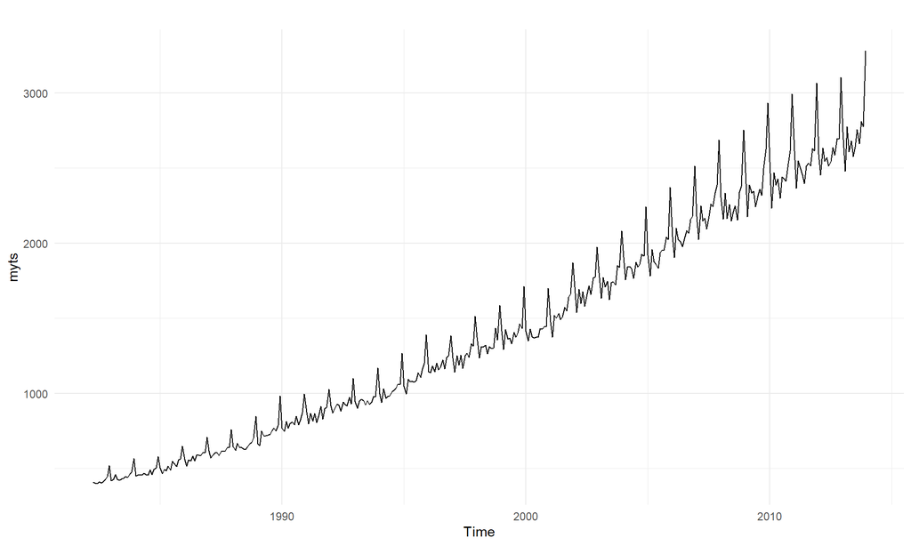

```r
autoplot(myts)+
  theme_minimal()
```

- The Seasonal variations are changing/growing as the time passes
- Since the seasonality is not steady, multiplicative is required

### b.

Apply Holt-Winters’ multiplicative method to the data. Experiment with making the trend damped.

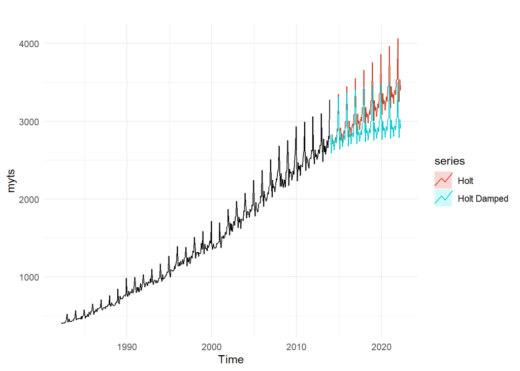

```r
myts_multi <- hw(myts, h=100, seasonal = "multiplicative")
myts_damp <- hw(myts, h=100, seasonal = "multiplicative", damped = TRUE)

autoplot(myts)+
  autolayer(myts_multi, series = "Holt", PI=FALSE)+
  autolayer(myts_damp, series = "Holt Damped", PI=FALSE)+
  theme_minimal()
```

### c.

Compare the RMSE of the one-step forecasts from the two methods. Which do you prefer?

```r
accuracy_multi <- accuracy(myts_multi)[2]
accuracy_damp <- accuracy(myts_damp)[2]

rmse_compare <- data.frame('Multiplicative'= accuracy_multi,
                           'Damped'=accuracy_damp)
rmse_compare <- as.data.frame(t(rmse_compare))

colnames(rmse_compare) <- c("Compare")

kable(rmse_compare, caption = "Comparison of Multiplicative models")
```

Comparison of Multiplicative models

|  | Compare |
| --- | --- |
| Multiplicative | 29.43051 |
| Damped | 29.63087 |

- The standard Multiplicative model yielded better results

```r
accuracy(myts_damp)
```

```
##                    ME     RMSE      MAE       MPE     MAPE     MASE
## Training set 4.244765 29.63087 22.26018 0.2959731 1.785469 0.292681
##                    ACF1
## Training set -0.2184672
```

### d.

Check that the residuals from the best method look like white noise.

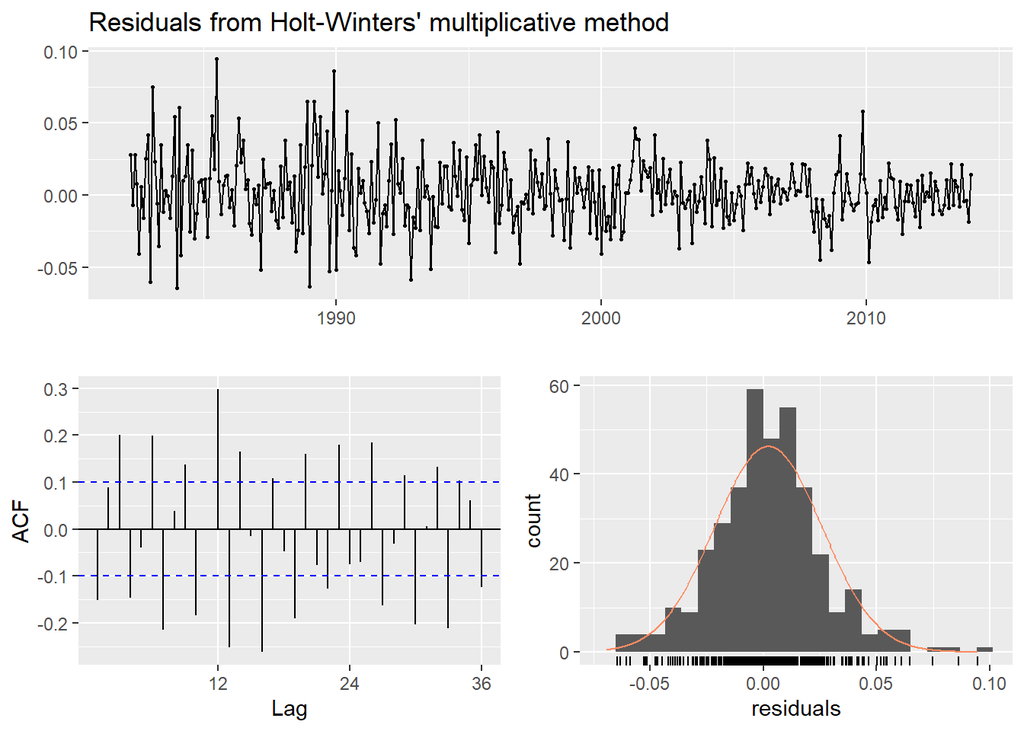

```
##
##  Ljung-Box test
##
## data:  Residuals from Holt-Winters' multiplicative method
## Q* = 244.86, df = 8, p-value < 2.2e-16
##
## Model df: 16.   Total lags used: 24
```

```r
checkresiduals(myts_multi)
```

- The histogram does look to have a normal distribution
- Looking at the ACF, there are a lot of levels outside the norm, there may be residuals outside of white noise.

### e.

Now find the test set RMSE, while training the model to the end of 2010. Can you beat the seasonal naïve approach from Exercise 8 in Section 3.7?

```r
myts.train <- window(myts, end=c(2010, 12))
myts.test <- window(myts, start=2011)
```

```r
myts.niave.train <- snaive(myts.train)
(myts.niave.acc <- accuracy(myts.niave.train,myts.test))
```

```
##                     ME      RMSE       MAE      MPE     MAPE     MASE
## Training set  73.94114  88.31208  75.13514 6.068915 6.134838 1.000000
## Test set     115.00000 127.92727 115.00000 4.459712 4.459712 1.530576
##                   ACF1 Theil's U
## Training set 0.6312891        NA
## Test set     0.2653013 0.7267171
```

```r
myts.holt.train <- hw(myts.train, seasonal = "multiplicative")
(myts.holt.acc <- accuracy(myts.holt.train, myts.test))
```

```
##                      ME     RMSE      MAE        MPE     MAPE      MASE
## Training set   2.594132 29.87520 22.43516  0.2383033 1.864671 0.2985975
## Test set     -29.588194 49.09806 38.39804 -1.1062616 1.458304 0.5110531
##                     ACF1 Theil's U
## Training set -0.03687893        NA
## Test set      0.09931874  0.267754
```

- The RMSE for Holt is the better fit in this case
  - Holt 29.86/49.1
  - Naive 88.31/127.92

## 7.9

For the same retail data, try an STL decomposition applied to the Box-Cox transformed series, followed by ETS on the seasonally adjusted data. How does that compare with your best previous forecasts on the test set?

```r
myts.stl <- stlf(myts.train, lambda = BoxCox.lambda(myts.train))
accuracy(myts.stl)
```

```
##                     ME     RMSE      MAE      MPE     MAPE      MASE
## Training set -1.077737 26.34835 19.95571 -0.02085 1.675349 0.2655976
##                     ACF1
## Training set -0.04737883
```

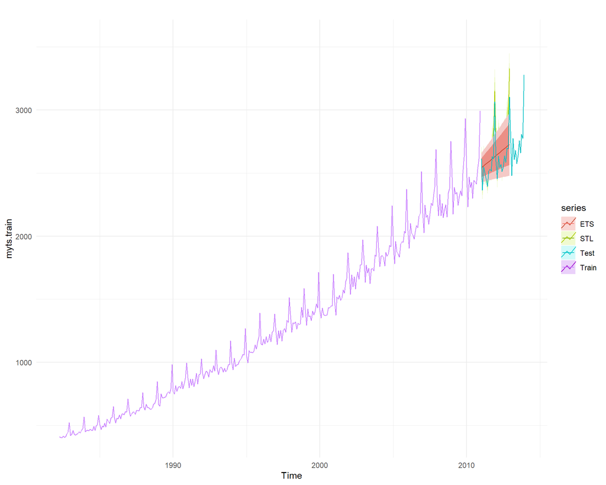

```r
myts.ets <- ets(seasadj(decompose(myts.train, "multiplicative")))

autoplot(myts.train, series = "Train")+
  autolayer(forecast(myts.stl, h=24), series = "STL")+
  autolayer(forecast(myts.ets, h=24), series = "ETS")+
  autolayer(myts.test, series = "Test")+
  theme_minimal()
```

- The STL model performed better than the ETS model by better fitting the data